# 003 ICU

Katie Gostic

11/1/2017

Notes on data formatting from Deborah Wentworth:

- symdur is symptom duration (days) prior to enrollment
- date info is for enrollment date
- fluvac6 and fluvac12 are flu vaccination in last 6 or last 12 months
- anyvac combines values from fluvac6 and fluvac12, whichever was collected for a given patient is reported.
- anyav is use of antivirals at any time
- anydx is any diagnosis in the medical history section
- flutype is subtype: 1=H1N1, 2=H3N2, 3=flu B, 4=PCR negative, 5=Inf A, subtype unknown, and 6=coinfection with multiple strains
- resolved is symptom resolution within 14 days
- country code is the 3 letter code for country of enrollment - think the abbreviations will be obvious

#### Visualize the relationship between age and prob of H1N1 infection

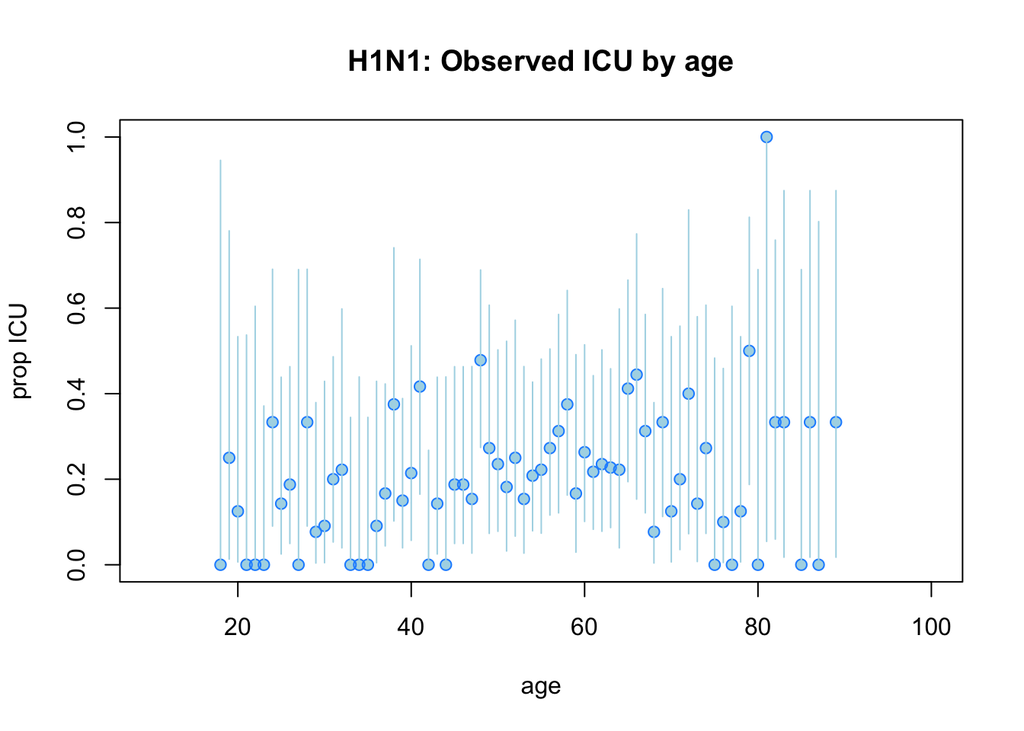

#### Visualize the relationship between age and prob of H3N2 infection

[figure not shown]

#### Visualize the relationship between country and prolonged symptoms

H1N1

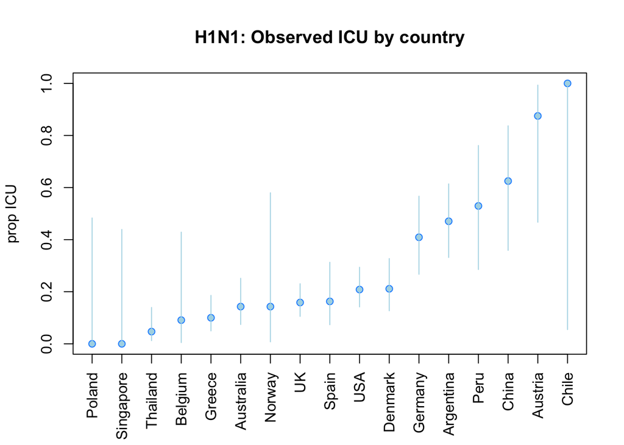

H3N2

[figure not shown]

#### Visualize the relationship between season and prob infection

H1N1

[figure not shown]

H3N2

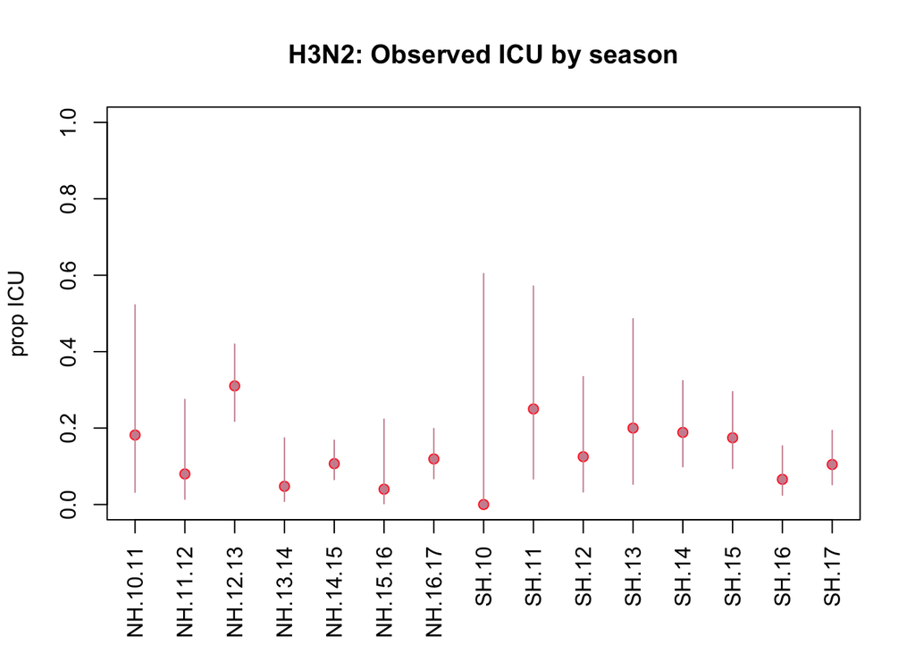

### H1N1 10-fold CV

We know the relationship between age and probability of infection should be non-linear. Use cross-validation to verify, and to choose the number of degrees of freedom to include in a spline

### H3N2 10-fold CV

We know the relationship between age and probability of infection should be non-linear. Use cross-validation to verify, and to choose the number of degrees of freedom to include in a spline

## Set up a logistic regression that includes the following predictors:

- age
- imprinting status
- vaccination status
- antiviral use
- season
- country

### Clean data for fitting

```
##
## Argentina Australia   Austria   Belgium     Chile     China   Denmark
##        51        70         8        11         1        16        71
##   Germany    Greece    Norway      Peru    Poland Singapore     Spain
##        44        90         7        17         6         7        43
##  Thailand        UK       USA
##        64       145       120
```

```
## [1] 771
```

### First fit a model where the only independent variable is age

Treat vaccination, antivial use, underlying symptoms, country and season as blocking variables with fixed effects

```r
library(splines)
## H1N1 fit to country, season and medical history only (no effect of age or imprinting)
fit0 = glm(anyicu ~ anyvac + anyav + anydx + country + season, data = train.H1N1, family = binomial)
summary(fit0)
```

```
##
## Call:
## glm(formula = anyicu ~ anyvac + anyav + anydx + country + season,
##     family = binomial, data = train.H1N1)
##
## Deviance Residuals:
##     Min       1Q   Median       3Q      Max
## -1.5453  -0.6613  -0.4494  -0.2057   2.7844
##
## Coefficients:
##                   Estimate Std. Error z value Pr(>|z|)
## (Intercept)        -0.2577     0.9267  -0.278 0.780946
## anyvac1            -0.5014     0.2645  -1.896 0.057967 .
## anyav1              0.9023     0.3701   2.438 0.014758 *
## anydx1              0.1423     0.2835   0.502 0.615677
## countryAustralia   -1.3385     0.6604  -2.027 0.042668 *
## countryBelgium     -3.6725     1.4707  -2.497 0.012520 *
## countryChina       -0.5282     0.9950  -0.531 0.595488
## countryDenmark     -2.0276     0.8381  -2.419 0.015547 *
## countryGermany     -1.1741     0.8648  -1.358 0.174611
## countryGreece      -3.2004     0.9237  -3.465 0.000531 ***
## countryNorway      -2.0557     1.3922  -1.477 0.139806
## countryOther       -1.8457     0.7939  -2.325 0.020083 *
## countryPeru         1.2666     0.9244   1.370 0.170648
## countryPoland     -18.0371  1580.3343  -0.011 0.990894
## countrySingapore  -15.2377  1263.0182  -0.012 0.990374
## countrySpain       -2.2862     0.9295  -2.460 0.013907 *
## countryThailand    -4.0069     0.9946  -4.029 5.61e-05 ***
## countryUSA         -1.6236     0.8036  -2.020 0.043343 *
## seasonNH.10.11      0.1713     0.4159   0.412 0.680450
## seasonNH.11.12     -0.8215     1.2437  -0.661 0.508907
## seasonNH.12.13      1.4766     0.8072   1.829 0.067347 .
## seasonNH.13.14     -0.2773     0.4438  -0.625 0.532092
## seasonNH.14.15      0.9353     0.7335   1.275 0.202231
## seasonNH.15.16     -0.4825     0.4220  -1.143 0.252846
## seasonNH.16.17    -14.0148  1311.7708  -0.011 0.991476
## seasonSH.10         0.7759     1.0039   0.773 0.439605
## seasonSH.11        -0.7901     0.9830  -0.804 0.421520
## seasonSH.12        -2.7255     1.4718  -1.852 0.064054 .
## seasonSH.13        -1.8549     0.9551  -1.942 0.052125 .
## seasonSH.14        -1.5239     1.4179  -1.075 0.282485
## seasonSH.15        -0.9607     1.1223  -0.856 0.391997
## seasonSH.16        -0.8317     0.7916  -1.051 0.293402
## seasonSH.17       -12.6771  1717.3593  -0.007 0.994110
## ---
## Signif. codes:  0 '***' 0.001 '**' 0.01 '*' 0.05 '.' 0.1 ' ' 1
##
## (Dispersion parameter for binomial family taken to be 1)
##
##     Null deviance: 638.15  on 660  degrees of freedom
## Residual deviance: 538.29  on 628  degrees of freedom
##   (37 observations deleted due to missingness)
## AIC: 604.29
##
## Number of Fisher Scoring iterations: 16
```

```r
## H1N1 fit to age only, plus fixed effects of vaccination, av use, underlying conditions, country and season
fit1 = glm(anyicu ~ ns(age,knots = 65) + anyvac + anyav + anydx + country + season, data = train.H1N1, family = binomial)
summary(fit1)
```

```
##
## Call:
## glm(formula = anyicu ~ ns(age, knots = 65) + anyvac + anyav +
##     anydx + country + season, family = binomial, data = train.H1N1)
##
## Deviance Residuals:
##     Min       1Q   Median       3Q      Max
## -1.5694  -0.6448  -0.4438  -0.1892   2.6537
##
## Coefficients:
##                        Estimate Std. Error z value Pr(>|z|)
## (Intercept)            -1.04827    1.00177  -1.046 0.295368
## ns(age, knots = 65)1    2.35335    0.88135   2.670 0.007581 **
## ns(age, knots = 65)2    0.80164    0.66646   1.203 0.229043
## anyvac1                -0.65385    0.27621  -2.367 0.017922 *
## anyav1                  0.90969    0.37526   2.424 0.015344 *
## anydx1                 -0.04474    0.29662  -0.151 0.880111
## countryAustralia       -1.15118    0.67536  -1.705 0.088279 .
## countryBelgium         -3.37643    1.47581  -2.288 0.022147 *
## countryChina           -0.48113    1.00619  -0.478 0.632529
## countryDenmark         -1.79118    0.84877  -2.110 0.034829 *
## countryGermany         -0.84550    0.87413  -0.967 0.333422
## countryGreece          -3.25240    0.93363  -3.484 0.000495 ***
## countryNorway          -2.10796    1.39707  -1.509 0.131340
## countryOther           -1.66592    0.80850  -2.061 0.039350 *
## countryPeru             1.55821    0.96791   1.610 0.107425
## countryPoland         -17.63978 1579.35815  -0.011 0.991089
## countrySingapore      -15.28269 1259.79302  -0.012 0.990321
## countrySpain           -2.22180    0.93627  -2.373 0.017642 *
## countryThailand        -4.02079    1.01137  -3.976 7.02e-05 ***
## countryUSA             -1.51471    0.81379  -1.861 0.062703 .
## seasonNH.10.11          0.03468    0.41967   0.083 0.934143
## seasonNH.11.12         -0.58469    1.24637  -0.469 0.638989
## seasonNH.12.13          1.23097    0.82612   1.490 0.136208
## seasonNH.13.14         -0.32499    0.44806  -0.725 0.468242
## seasonNH.14.15          0.78149    0.74911   1.043 0.296845
## seasonNH.15.16         -0.69230    0.42820  -1.617 0.105928
## seasonNH.16.17        -14.02850 1289.18078  -0.011 0.991318
## seasonSH.10             1.09026    1.01068   1.079 0.280707
## seasonSH.11            -0.77777    0.98576  -0.789 0.430106
## seasonSH.12            -2.61300    1.48317  -1.762 0.078109 .
## seasonSH.13            -1.66177    0.94796  -1.753 0.079604 .
## seasonSH.14            -1.74843    1.40521  -1.244 0.213411
## seasonSH.15            -1.15263    1.10357  -1.044 0.296277
## seasonSH.16            -1.00617    0.80278  -1.253 0.210074
## seasonSH.17           -12.94257 1720.41044  -0.008 0.993998
## ---
## Signif. codes:  0 '***' 0.001 '**' 0.01 '*' 0.05 '.' 0.1 ' ' 1
##
## (Dispersion parameter for binomial family taken to be 1)
##
##     Null deviance: 638.15  on 660  degrees of freedom
## Residual deviance: 529.92  on 626  degrees of freedom
##   (37 observations deleted due to missingness)
## AIC: 599.92
##
## Number of Fisher Scoring iterations: 16
```

```r
## H1N1 fit to age plus imprinting, plus fixed effects of vaccination, av use, underlying conditions, country and season
fit2 = glm(anyicu ~ ns(age, knots = 65) + p.g1.protection + anyvac + anyav + anydx + country + season, data = train.H1N1, family = binomial)
summary(fit2)
```

```
##
## Call:
## glm(formula = anyicu ~ ns(age, knots = 65) + p.g1.protection +
##     anyvac + anyav + anydx + country + season, family = binomial,
##     data = train.H1N1)
##
## Deviance Residuals:
##     Min       1Q   Median       3Q      Max
## -1.5700  -0.6454  -0.4452  -0.1900   2.6538
##
## Coefficients:
##                        Estimate Std. Error z value Pr(>|z|)
## (Intercept)            -1.05186    1.00244  -1.049 0.294037
## ns(age, knots = 65)1    2.45936    1.26723   1.941 0.052290 .
## ns(age, knots = 65)2    0.84304    0.75481   1.117 0.264040
## p.g1.protection        -0.05458    0.46745  -0.117 0.907044
## anyvac1                -0.65325    0.27628  -2.364 0.018058 *
## anyav1                  0.90701    0.37588   2.413 0.015820 *
## anydx1                 -0.04335    0.29690  -0.146 0.883911
## countryAustralia       -1.14919    0.67549  -1.701 0.088894 .
## countryBelgium         -3.37256    1.47543  -2.286 0.022265 *
## countryChina           -0.47366    1.00824  -0.470 0.638507
## countryDenmark         -1.78950    0.84878  -2.108 0.035004 *
## countryGermany         -0.84363    0.87414  -0.965 0.334496
## countryGreece          -3.24739    0.93451  -3.475 0.000511 ***
## countryNorway          -2.10296    1.39737  -1.505 0.132339
## countryOther           -1.66014    0.80980  -2.050 0.040358 *
## countryPeru             1.56233    0.96862   1.613 0.106757
## countryPoland         -17.63108 1581.03483  -0.011 0.991102
## countrySingapore      -15.27261 1259.43384  -0.012 0.990325
## countrySpain           -2.22114    0.93617  -2.373 0.017664 *
## countryThailand        -4.01991    1.01130  -3.975 7.04e-05 ***
## countryUSA             -1.50878    0.81525  -1.851 0.064214 .
## seasonNH.10.11          0.03367    0.41977   0.080 0.936073
## seasonNH.11.12         -0.57950    1.24739  -0.465 0.642236
## seasonNH.12.13          1.22680    0.82590   1.485 0.137437
## seasonNH.13.14         -0.33204    0.45227  -0.734 0.462849
## seasonNH.14.15          0.77570    0.75100   1.033 0.301652
## seasonNH.15.16         -0.70067    0.43425  -1.614 0.106628
## seasonNH.16.17        -14.02654 1288.49536  -0.011 0.991314
## seasonSH.10             1.08955    1.01136   1.077 0.281339
## seasonSH.11            -0.77871    0.98592  -0.790 0.429628
## seasonSH.12            -2.60832    1.48397  -1.758 0.078803 .
## seasonSH.13            -1.65853    0.94844  -1.749 0.080346 .
## seasonSH.14            -1.75502    1.40835  -1.246 0.212706
## seasonSH.15            -1.15282    1.10380  -1.044 0.296295
## seasonSH.16            -1.00912    0.80304  -1.257 0.208888
## seasonSH.17           -12.93945 1720.38331  -0.008 0.993999
## ---
## Signif. codes:  0 '***' 0.001 '**' 0.01 '*' 0.05 '.' 0.1 ' ' 1
##
## (Dispersion parameter for binomial family taken to be 1)
##
##     Null deviance: 638.15  on 660  degrees of freedom
## Residual deviance: 529.91  on 625  degrees of freedom
##   (37 observations deleted due to missingness)
## AIC: 601.91
##
## Number of Fisher Scoring iterations: 16
```

```r
par(mfrow = c(1, 2), las = 3, mar = c(6, 6, 6, 3), cex.axis = .7)
library(gam)
```

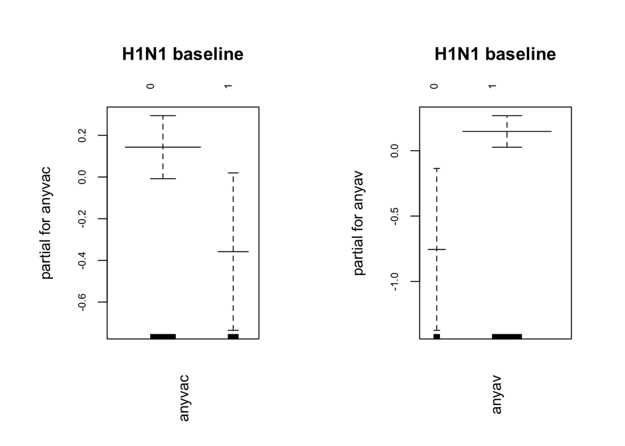

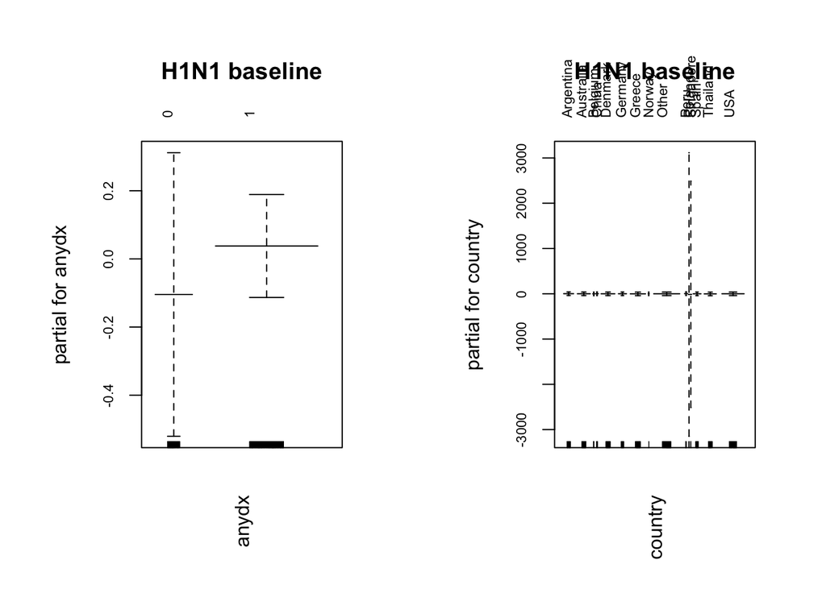

```r
plot.gam(fit0, se = T, col = 'dodgerblue', main = 'H1N1 baseline')
```

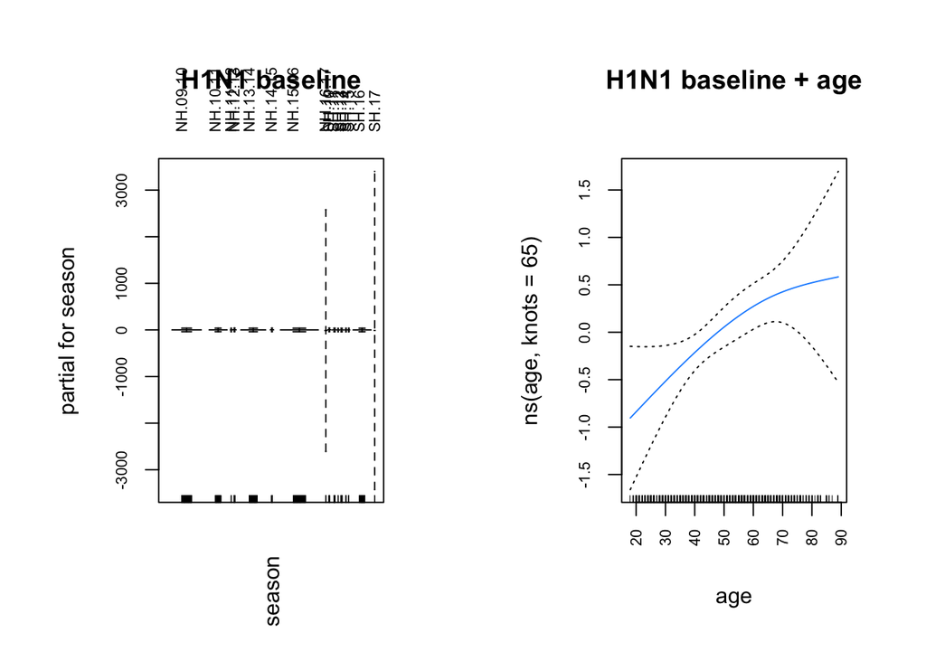

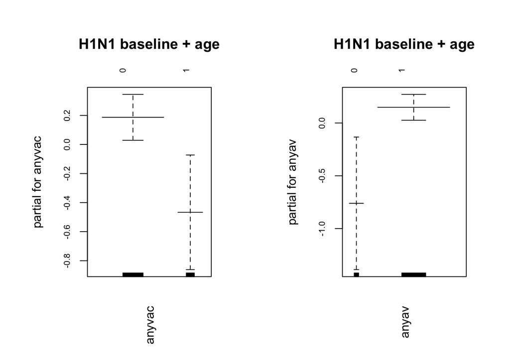

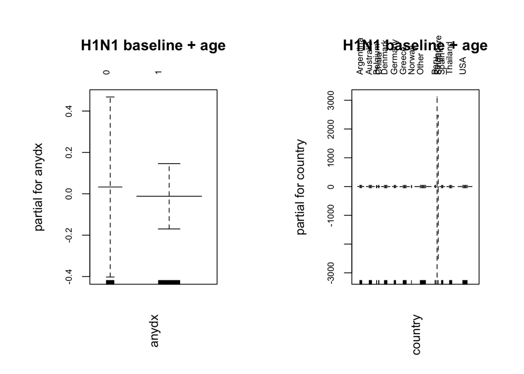

```r
plot.gam(fit1, se = T, col = 'dodgerblue', main = 'H1N1 baseline + age')
```

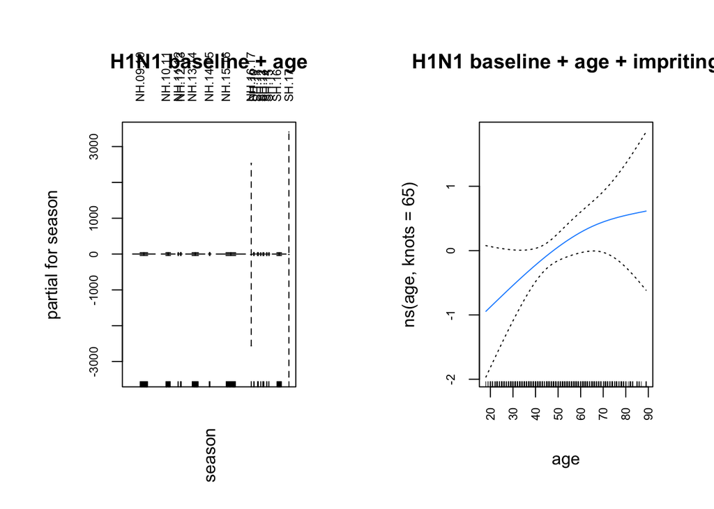

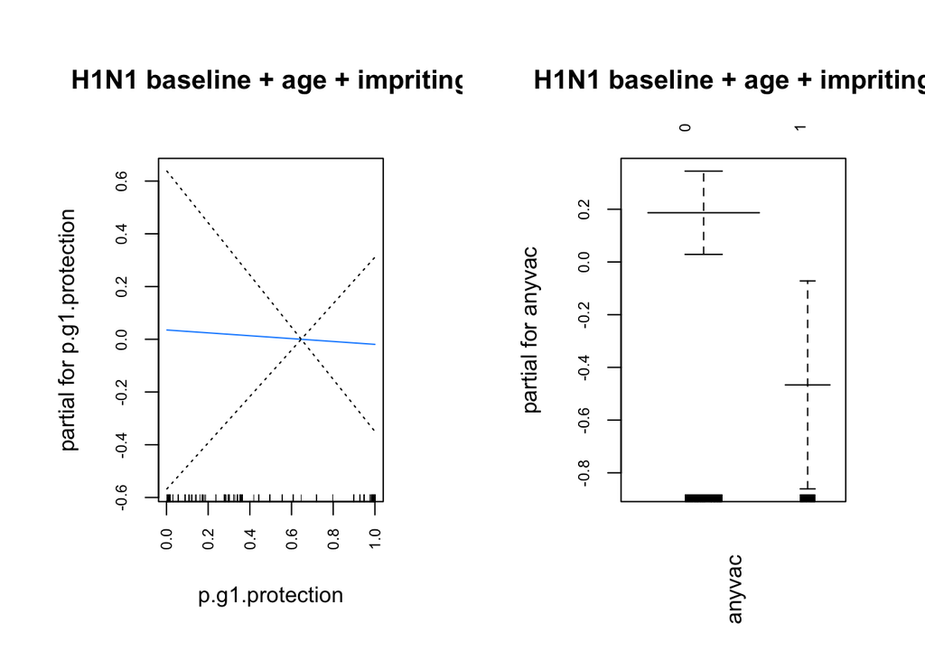

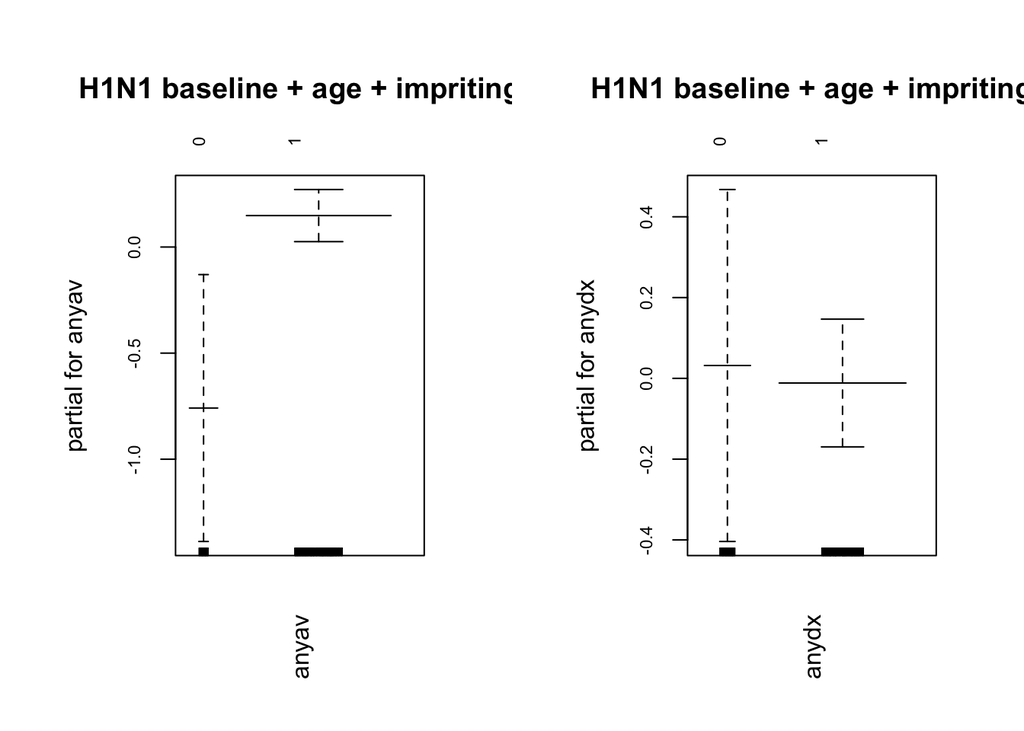

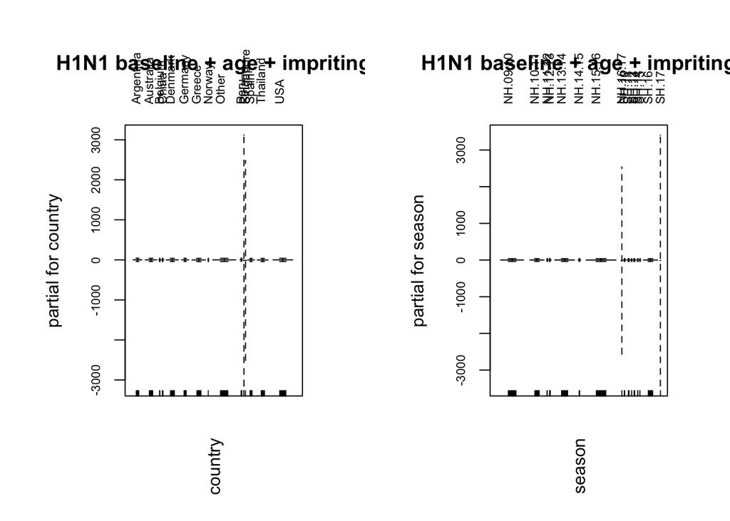

```r
plot.gam(fit2, se = T, col = 'dodgerblue', main = 'H1N1 baseline + age + impriting')
```

```r
pdf('003ICU_H1N1.pdf')
plot.gam(fit2, se = T, col = 'dodgerblue', main = 'H1N1 baseline + age + impriting')
dev.off()
```

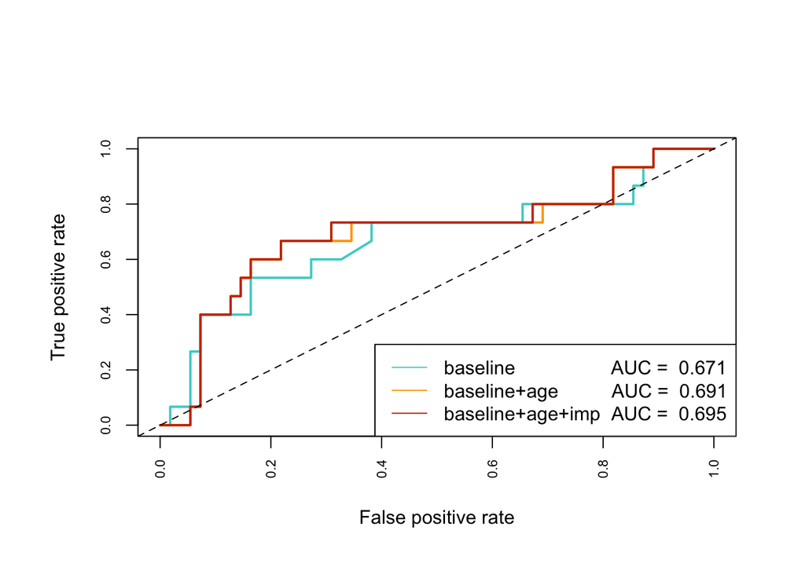

```r
## Test performance on test data
# Predict probs for each patient
probs0 = predict(fit0, newdata = test.H1N1, type = 'response')
probs1 = predict(fit1, newdata = test.H1N1, type = 'response')
probs2 = predict(fit2, newdata = test.H1N1, type = 'response')

# Create a predict object
pr0 = prediction(probs0, test.H1N1$anyicu)
pr1 = prediction(probs1, test.H1N1$anyicu)
pr2 = prediction(probs2, test.H1N1$anyicu)

# Assess tp and fp
prf0 = performance(pr0, measure = 'tpr', x.measure = 'fpr')
prf1 = performance(pr1, measure = 'tpr', x.measure = 'fpr')
prf2 = performance(pr2, measure = 'tpr', x.measure = 'fpr')

# Calculate AUCs
auc = sapply(list(pr0, pr1, pr2), FUN = function(xx){aa = performance(xx, measure = 'auc')
                                                                      round(aa@y.values[[1]], 3) })

# Plot AUC
par(mfrow = c(1,1))
plot(prf0, lwd = 2, col = cols[3])
plot(prf1, col = cols[2], add = TRUE, lwd = 2)
plot(prf2, col = cols[1], add = TRUE, lwd = 2)
abline(a = 0, b = 1, lty = 2)
legend('bottomright', paste(c('baseline                  AUC = ', 'baseline+age          AUC = ', 'baseline+age+imp  AUC = '), auc), col = cols[3:1], lty = 1)
```

```r
pdf('003ICU_AUC_H1N1.pdf')
par(lwd = 3.5, cex = 1.5, cex.axis = 1.5, cex.lab = 1.5)
# Plot AUC
par(mfrow = c(1,1))
plot(prf0, col = cols[3])
plot(prf1, col = cols[2], add = TRUE)
plot(prf2, col = cols[1], add = TRUE)
abline(a = 0, b = 1)
legend('bottomright', paste(c('baseline                  AUC = ', 'baseline+age          AUC = ', 'baseline+age+imp  AUC = '), auc), col = cols[3:1], lty = 1, bty = 'n', cex = 1.5)
dev.off()
```

```r
AIC = c(fit0$aic, fit1$aic, fit2$aic); names(AIC) =  c('baseline', 'baeline+age', 'baseline+age+imp')
del.AIC = sort(AIC - min(AIC))
del.AIC
```

```
##      baeline+age baseline+age+imp         baseline
##         0.000000         1.986393         4.370454
```

```r
load('master.AIC.table.H1N1.RData')
master.AIC.table['003ICU',  c('baseline', 'baseline+age', 'baseline+age+imp')] = AIC - min(AIC)
save(master.AIC.table, file = 'master.AIC.table.H1N1.RData')
rm(master.AIC.table)
```

### Clean H3N2 data for fitting

```
##
## Argentina Australia   Belgium     China   Denmark   Germany    Greece
##       117       123         5         7        32        21        24
##      Peru Singapore     Spain  Thailand        UK       USA
##         9        24        31       125        93       180
```

```
## [1] 791
```

```r
## H3N2 fit to country, season and medical history only (no effect of age or imprinting)
fit0 = glm(anyicu ~ anyvac + anyav + anydx + country + season, data = train.H3N2, family = binomial)
summary(fit0)
```

```
##
## Call:
## glm(formula = anyicu ~ anyvac + anyav + anydx + country + season,
##     family = binomial, data = train.H3N2)
##
## Deviance Residuals:
##     Min       1Q   Median       3Q      Max
## -1.4273  -0.5245  -0.4059  -0.1795   3.0122
##
## Coefficients:
##                    Estimate Std. Error z value Pr(>|z|)
## (Intercept)        -2.97476    1.48171  -2.008  0.04468 *
## anyvac1            -0.44319    0.27565  -1.608  0.10788
## anyav1              0.28418    0.33993   0.836  0.40315
## anydx1              1.75758    0.64319   2.733  0.00628 **
## countryAustralia   -1.73565    0.59121  -2.936  0.00333 **
## countryBelgium      1.00227    1.55931   0.643  0.52038
## countryChina        0.04961    1.64987   0.030  0.97601
## countryDenmark     -1.10882    1.08630  -1.021  0.30738
## countryGermany      1.11507    0.96338   1.157  0.24708
## countryOther       -0.95688    0.81182  -1.179  0.23852
## countryPeru        -0.60932    1.21392  -0.502  0.61571
## countrySingapore  -16.35708  820.42395  -0.020  0.98409
## countryThailand    -2.43998    0.77527  -3.147  0.00165 **
## countryUSA         -0.50643    0.79002  -0.641  0.52150
## seasonNH.11.12     -0.12212    1.26174  -0.097  0.92290
## seasonNH.12.13      1.11585    1.02840   1.085  0.27791
## seasonNH.13.14     -0.61187    1.32153  -0.463  0.64337
## seasonNH.14.15     -0.03170    1.05005  -0.030  0.97591
## seasonNH.15.16      0.08011    1.50068   0.053  0.95743
## seasonNH.16.17     -0.34850    1.10862  -0.314  0.75325
## seasonSH.10       -15.90984 1811.78364  -0.009  0.99299
## seasonSH.11         0.71160    1.40201   0.508  0.61177
## seasonSH.12         0.71145    1.29703   0.549  0.58333
## seasonSH.13         0.55635    1.46075   0.381  0.70330
## seasonSH.14         0.31557    1.29748   0.243  0.80784
## seasonSH.15         0.60452    1.28699   0.470  0.63856
## seasonSH.16         0.68525    1.33227   0.514  0.60701
## seasonSH.17        -0.42014    1.31156  -0.320  0.74871
## ---
## Signif. codes:  0 '***' 0.001 '**' 0.01 '*' 0.05 '.' 0.1 ' ' 1
##
## (Dispersion parameter for binomial family taken to be 1)
##
##     Null deviance: 541.89  on 689  degrees of freedom
## Residual deviance: 459.05  on 662  degrees of freedom
##   (22 observations deleted due to missingness)
## AIC: 515.05
##
## Number of Fisher Scoring iterations: 16
```

```r
## H3N2 fit to age only, plus fixed effects of vaccination, av use, underlying conditions, country and season
fit1 = glm(anyicu ~ ns(age, knots = 65) + anyvac + anyav + anydx + country + season, data = train.H3N2, family = binomial)
summary(fit1)
```

```
##
## Call:
## glm(formula = anyicu ~ ns(age, knots = 65) + anyvac + anyav +
##     anydx + country + season, family = binomial, data = train.H3N2)
##
## Deviance Residuals:
##     Min       1Q   Median       3Q      Max
## -1.4186  -0.5467  -0.3911  -0.1716   2.9892
##
## Coefficients:
##                        Estimate Std. Error z value Pr(>|z|)
## (Intercept)            -2.91347    1.53069  -1.903  0.05699 .
## ns(age, knots = 65)1   -0.27649    0.96329  -0.287  0.77409
## ns(age, knots = 65)2   -1.23439    0.59099  -2.089  0.03674 *
## anyvac1                -0.34602    0.28004  -1.236  0.21660
## anyav1                  0.23213    0.34077   0.681  0.49574
## anydx1                  1.84806    0.65826   2.807  0.00499 **
## countryAustralia       -1.87424    0.60653  -3.090  0.00200 **
## countryBelgium          0.87862    1.55957   0.563  0.57318
## countryChina            0.19764    1.69319   0.117  0.90708
## countryDenmark         -1.23577    1.08855  -1.135  0.25627
## countryGermany          0.96006    0.96773   0.992  0.32116
## countryOther           -1.11438    0.81877  -1.361  0.17350
## countryPeru            -0.82185    1.22448  -0.671  0.50210
## countrySingapore      -16.60206  813.38076  -0.020  0.98372
## countryThailand        -2.49041    0.78468  -3.174  0.00150 **
## countryUSA             -0.70150    0.80097  -0.876  0.38113
## seasonNH.11.12         -0.08744    1.27948  -0.068  0.94551
## seasonNH.12.13          1.20165    1.05636   1.138  0.25531
## seasonNH.13.14         -0.45459    1.33492  -0.341  0.73345
## seasonNH.14.15          0.05004    1.07466   0.047  0.96286
## seasonNH.15.16          0.31737    1.52308   0.208  0.83493
## seasonNH.16.17         -0.31392    1.12970  -0.278  0.78111
## seasonSH.10           -15.66464 1808.66893  -0.009  0.99309
## seasonSH.11             0.58546    1.42748   0.410  0.68171
## seasonSH.12             0.82644    1.31684   0.628  0.53027
## seasonSH.13             0.51994    1.48818   0.349  0.72680
## seasonSH.14             0.37945    1.31681   0.288  0.77323
## seasonSH.15             0.70491    1.30900   0.539  0.59022
## seasonSH.16             0.80299    1.35843   0.591  0.55444
## seasonSH.17            -0.42557    1.33470  -0.319  0.74984
## ---
## Signif. codes:  0 '***' 0.001 '**' 0.01 '*' 0.05 '.' 0.1 ' ' 1
##
## (Dispersion parameter for binomial family taken to be 1)
##
##     Null deviance: 541.89  on 689  degrees of freedom
## Residual deviance: 454.27  on 660  degrees of freedom
##   (22 observations deleted due to missingness)
## AIC: 514.27
##
## Number of Fisher Scoring iterations: 16
```

```r
## H3N2 fit to age plus imprinting, plus fixed effects of vaccination, av use, underlying conditions, country and season
fit2 = glm(anyicu ~ ns(age, knots = 65) + p.g2.protection + anyvac + anyav + anydx + country + season, data = train.H3N2, family = binomial)
summary(fit2)
```

```
##
## Call:
## glm(formula = anyicu ~ ns(age, knots = 65) + p.g2.protection +
##     anyvac + anyav + anydx + country + season, family = binomial,
##     data = train.H3N2)
##
## Deviance Residuals:
##     Min       1Q   Median       3Q      Max
## -1.4114  -0.5370  -0.3831  -0.1754   2.8972
##
## Coefficients:
##                        Estimate Std. Error z value Pr(>|z|)
## (Intercept)            -2.04453    1.68331  -1.215  0.22452
## ns(age, knots = 65)1   -1.81520    1.58295  -1.147  0.25150
## ns(age, knots = 65)2   -1.66936    0.68990  -2.420  0.01553 *
## p.g2.protection        -0.85685    0.71773  -1.194  0.23254
## anyvac1                -0.36306    0.28117  -1.291  0.19662
## anyav1                  0.18861    0.34215   0.551  0.58145
## anydx1                  1.83679    0.65278   2.814  0.00490 **
## countryAustralia       -1.87961    0.61067  -3.078  0.00208 **
## countryBelgium          0.99933    1.56476   0.639  0.52305
## countryChina            0.23084    1.69153   0.136  0.89145
## countryDenmark         -1.23885    1.08980  -1.137  0.25564
## countryGermany          0.87057    0.97338   0.894  0.37112
## countryOther           -1.18744    0.82177  -1.445  0.14847
## countryPeru            -0.93820    1.22373  -0.767  0.44328
## countrySingapore      -16.62159  815.77608  -0.020  0.98374
## countryThailand        -2.53741    0.78650  -3.226  0.00125 **
## countryUSA             -0.73806    0.80270  -0.919  0.35785
## seasonNH.11.12         -0.01598    1.28167  -0.012  0.99005
## seasonNH.12.13          1.30659    1.06134   1.231  0.21829
## seasonNH.13.14         -0.35783    1.34935  -0.265  0.79087
## seasonNH.14.15          0.17842    1.08104   0.165  0.86891
## seasonNH.15.16          0.39793    1.52582   0.261  0.79425
## seasonNH.16.17         -0.15539    1.13704  -0.137  0.89130
## seasonSH.10           -15.62404 1808.06619  -0.009  0.99311
## seasonSH.11             0.73890    1.43148   0.516  0.60573
## seasonSH.12             0.85317    1.31833   0.647  0.51753
## seasonSH.13             0.53587    1.49909   0.357  0.72075
## seasonSH.14             0.39303    1.31798   0.298  0.76555
## seasonSH.15             0.72033    1.30940   0.550  0.58223
## seasonSH.16             0.87309    1.36080   0.642  0.52113
## seasonSH.17            -0.35304    1.33720  -0.264  0.79177
## ---
## Signif. codes:  0 '***' 0.001 '**' 0.01 '*' 0.05 '.' 0.1 ' ' 1
##
## (Dispersion parameter for binomial family taken to be 1)
##
##     Null deviance: 541.89  on 689  degrees of freedom
## Residual deviance: 452.76  on 659  degrees of freedom
##   (22 observations deleted due to missingness)
## AIC: 514.76
##
## Number of Fisher Scoring iterations: 16
```

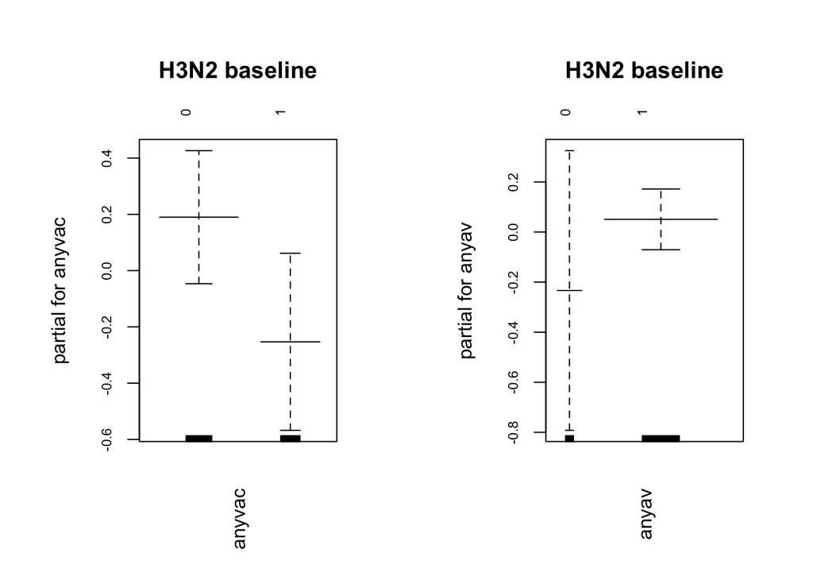

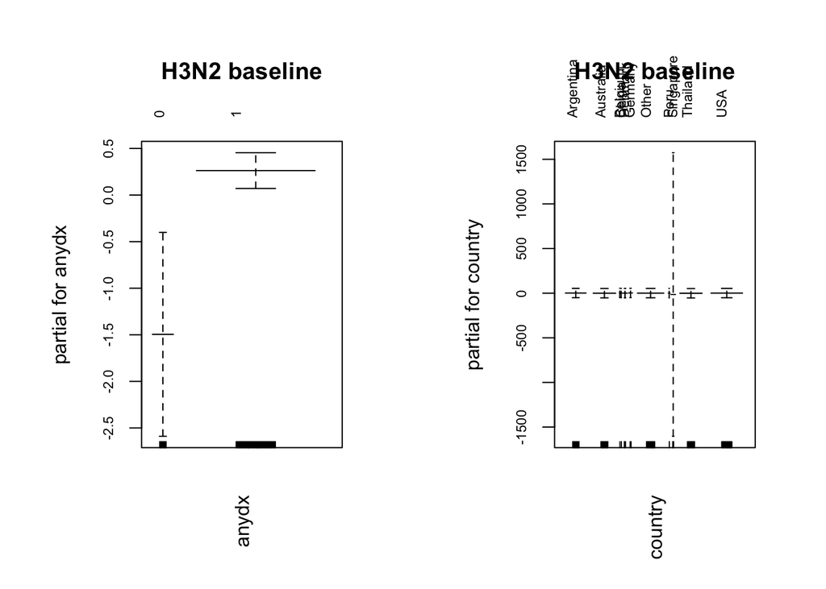

```r
## Plot the fits for each model side by side
par(mfrow = c(1, 2), las = 3, mar = c(6, 6, 6, 3), cex.axis = .7)
library(gam)
plot.gam(fit0, se = T, col = 'firebrick1', main = 'H3N2 baseline')
```

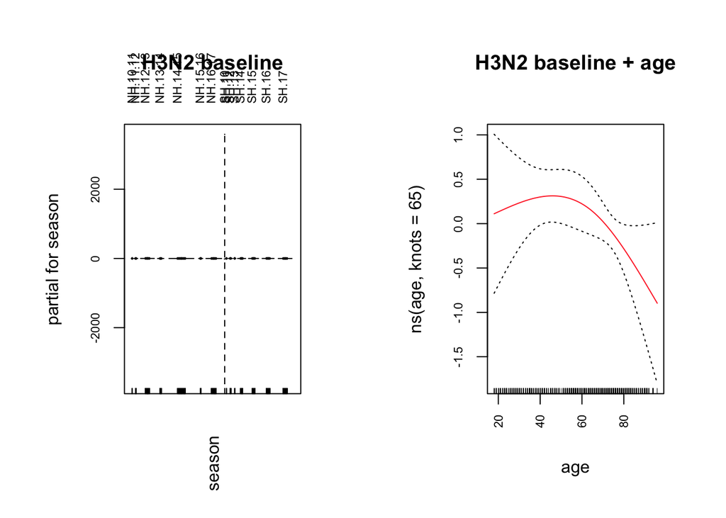

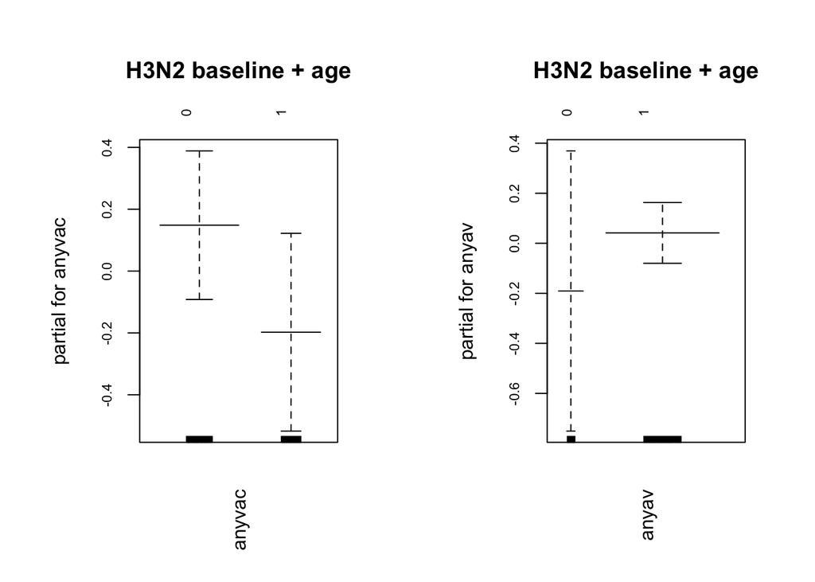

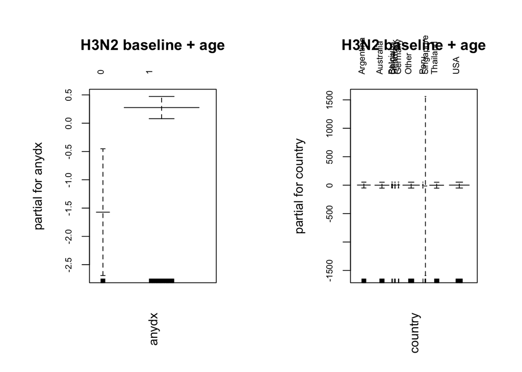

```r
plot.gam(fit1, se = T, col = 'firebrick1', main = 'H3N2 baseline + age')
```

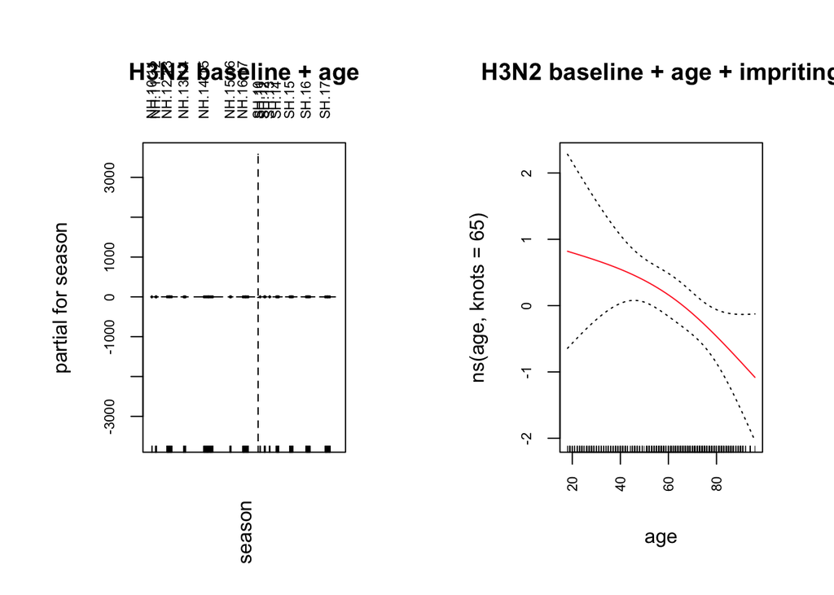

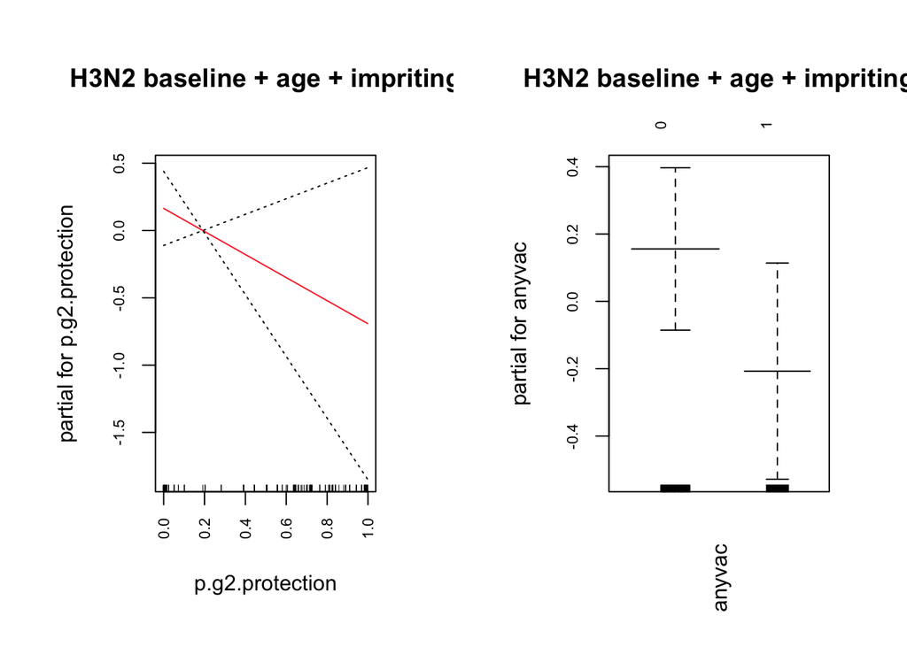

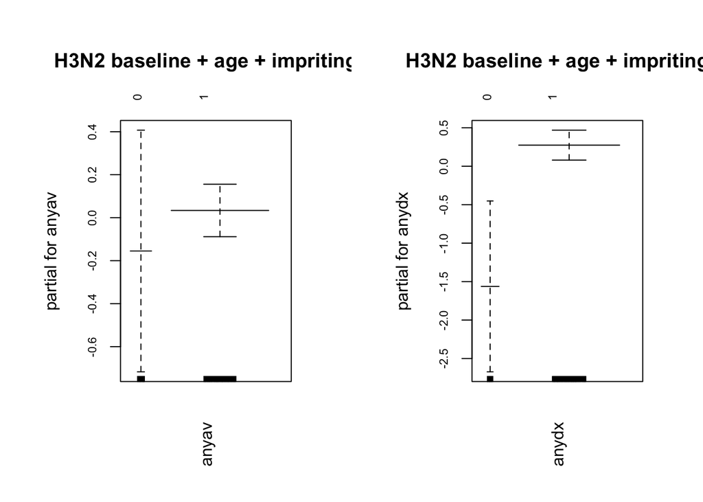

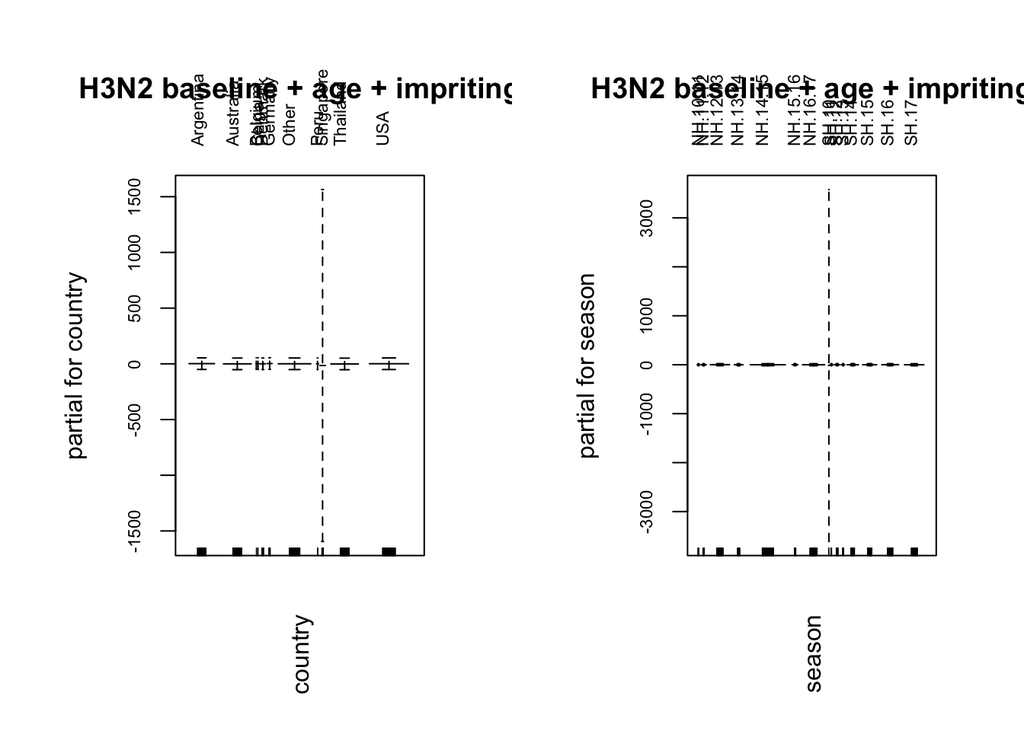

```r
plot.gam(fit2, se = T, col = 'firebrick1', main = 'H3N2 baseline + age + impriting')
```

```r
pdf('003ICU_H3N2.pdf')
plot.gam(fit2, se = T, col = 'firebrick1', main = 'H3N2 baseline + age + impriting')
dev.off()
```

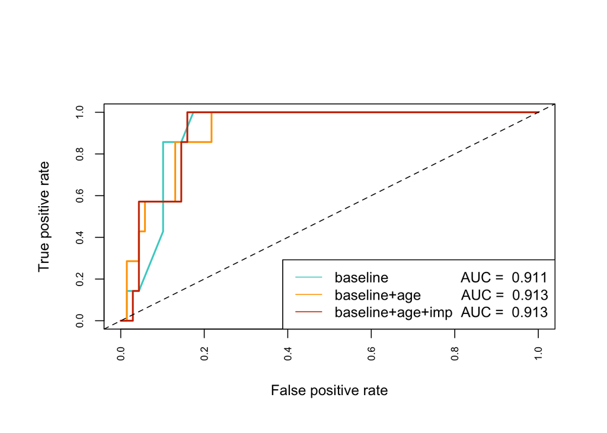

```r
# Test performance on test data
# Predict probs for each patient
probs0 = predict(fit0, newdata = test.H3N2, type = 'response')
probs1 = predict(fit1, newdata = test.H3N2, type = 'response')
probs2 = predict(fit2, newdata = test.H3N2, type = 'response')

# Create a predict object
pr0 = prediction(probs0, test.H3N2$anyicu)
pr1 = prediction(probs1, test.H3N2$anyicu)
pr2 = prediction(probs2, test.H3N2$anyicu)

# Assess tp and fp
prf0 = performance(pr0, measure = 'tpr', x.measure = 'fpr')
prf1 = performance(pr1, measure = 'tpr', x.measure = 'fpr')
prf2 = performance(pr2, measure = 'tpr', x.measure = 'fpr')

# Calculate AUCs
auc = sapply(list(pr0, pr1, pr2), FUN = function(xx){aa = performance(xx, measure = 'auc')
                                                                      round(aa@y.values[[1]], 3) })

# Plot AUC
par(mfrow = c(1,1))
plot(prf0, lwd = 2, col = cols[3])
plot(prf1, col = cols[2], add = TRUE, lwd = 2)
plot(prf2, col = cols[1], add = TRUE, lwd = 2)
abline(a = 0, b = 1, lty = 2)
legend('bottomright', paste(c('baseline                  AUC = ', 'baseline+age          AUC = ', 'baseline+age+imp  AUC = '), auc), col = cols[3:1], lty = 1)
```

```r
pdf('003ICU_AUC_H3N2.pdf')
par(lwd = 3.5, cex = 1.5, cex.axis = 1.5, cex.lab = 1.5)
# Plot AUC
par(mfrow = c(1,1))
plot(prf0, col = cols[3])
plot(prf1, col = cols[2], add = TRUE)
plot(prf2, col = cols[1], add = TRUE)
abline(a = 0, b = 1)
legend('bottomright', paste(c('baseline                  AUC = ', 'baseline+age          AUC = ', 'baseline+age+imp  AUC = '), auc), col = cols[3:1], lty = 1, bty = 'n', cex = 1.5)
dev.off()
```

```r
AIC = c(fit0$aic, fit1$aic, fit2$aic); names(AIC) =  c('baseline', 'baseline+age', 'baseline+age+imp')
del.AIC = sort(AIC - min(AIC))
del.AIC
```

```
##     baseline+age baseline+age+imp         baseline
##        0.0000000        0.4877861        0.7810800
```

```r
load('master.AIC.table.H3N2.RData')
master.AIC.table['003ICU',  c('baseline', 'baseline+age', 'baseline+age+imp')] = AIC - min(AIC)
save(master.AIC.table, file = 'master.AIC.table.H3N2.RData')
rm(master.AIC.table)
```